# Just the Facts - An Intuitive Approach to Understanding Climate Change

Kyle Brewster

Climate change is a topic that has taken many names over the past decades and has drawn supporters to both sides of the conversation. Those who believe in “global warming” say that trends in global and local climate changes are a result of human-activities, while others believe that recent changes are part of trends that have been going on for millennia. To truly understand the issue without being swayed by rhetoric from either side of the discussion, we can analyze the raw data.

Figure 1 as shown below displays temperature anomalies from the years 1 to 1979. The blue line represents the regression model fitted to this data The red vertical line represents the year 1880. It would be interesting to look trends before and after 1880 since it is shortly after the end of the Industrial Revolution, a point in time where emissions from human activity was beginning to increase due to developments in technology.

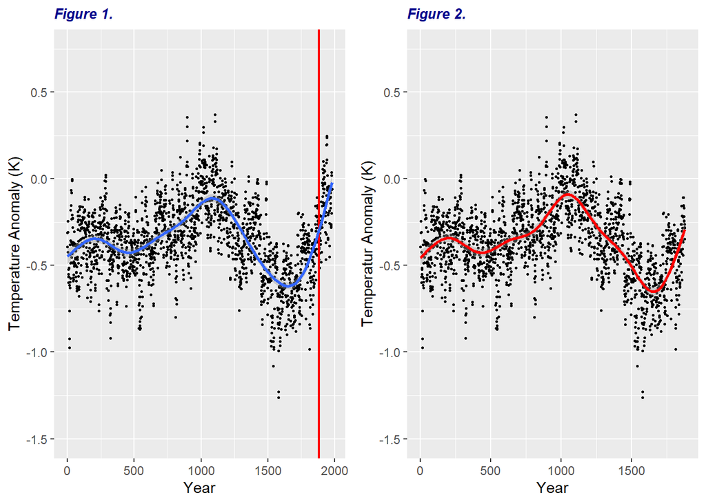

Figure 2 represents data from the same data filtered to only include years prior to 1880, where we will claim that human emissions were at relatively insignificant levels. The red line represents the regression model fitted to the Figure 2 data. Looking at the models in Figure 1 and Figure 2, we can see that the models don’t present convincing evidence of a trend that explains our values.

If our cutoff date was closer to the median year of the data, we could perhaps use a regression-discontinuity in our analysis; however, due to the differences in span of time, perhaps it would be more insightful to use our model from Figure 2 of the pre-1880 data to make predictions for the years after 1880 and compare those predictions to the truth as we know from Figure 1.

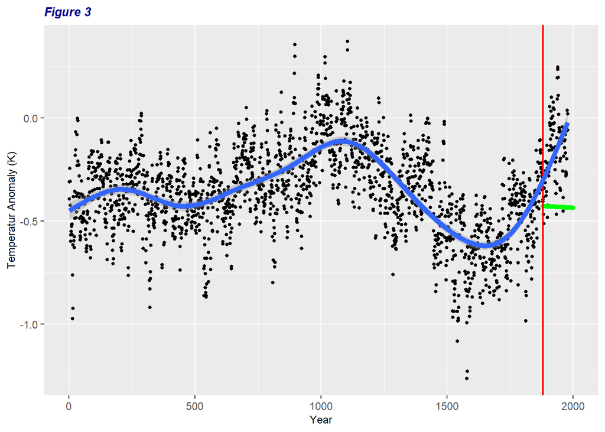

The green line of figure 3 represents the predicted values based on the model from the Figure 2 pre-1880 data superimposed on the original graph of Figure 1. This is interesting because the predictions from Figure 2 model are lower than the values of the actual data.

These results suggest that if historic trends in global temperature changes were to have continued from the pre-1880 values, then the true values should have been lower. The questions we must ask is why this discrepancy exists? Is the rise in temperature anomalies a result of a natural global heating, or can the change be explained by other factors? While our analysis so far doesn’t allow us to make any definite claims about climate change, perhaps we can look at more data to get some answers. In the next data set, we will look at data sources from the GISTEMP survey conducted by NASA containing temperature anomalies from the year 1880 and onward.

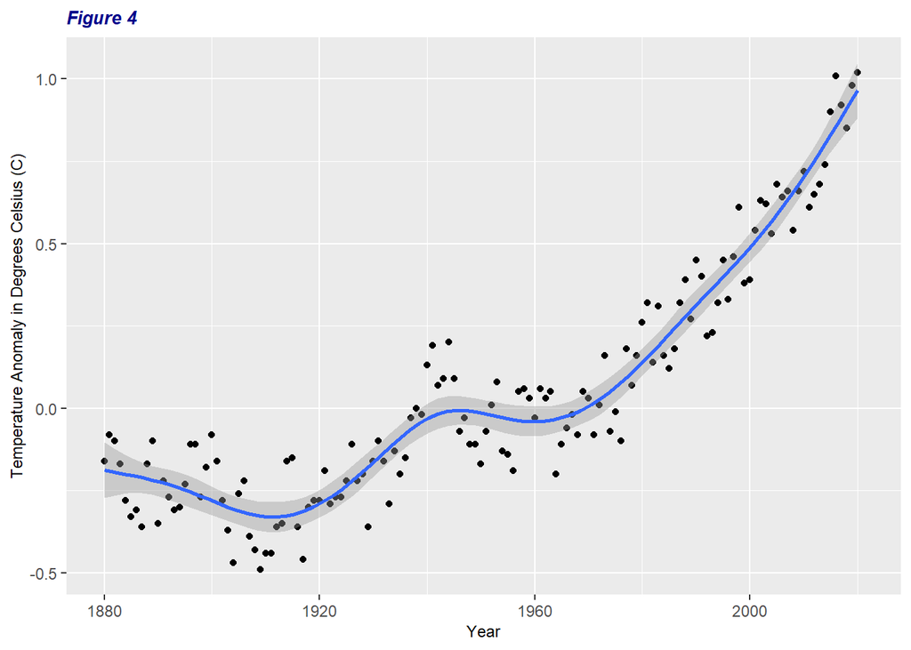

The upward trend in the NASA data matches the upward trend in the post-1880 data, so we can have some confidence in the reliability of our data. Now that we have data up to 2020, we can also consider recent data on human activities.

#### C A R B O N

Carbon dioxide (CO2) emissions compose the largest portion of greenhouse gas emissions. The combustion of gasoline for transportation, burning of coal for electricity, or degradation of social quality from poor soil management help contribute to higher CO2 emissions. Figure 5 displays the global amount of carbon emissions in billions of tons and Figure 6 shows the log of global emissions in tons. The fit of the regression lines suggests that the increase in carbon is an exponential trend.

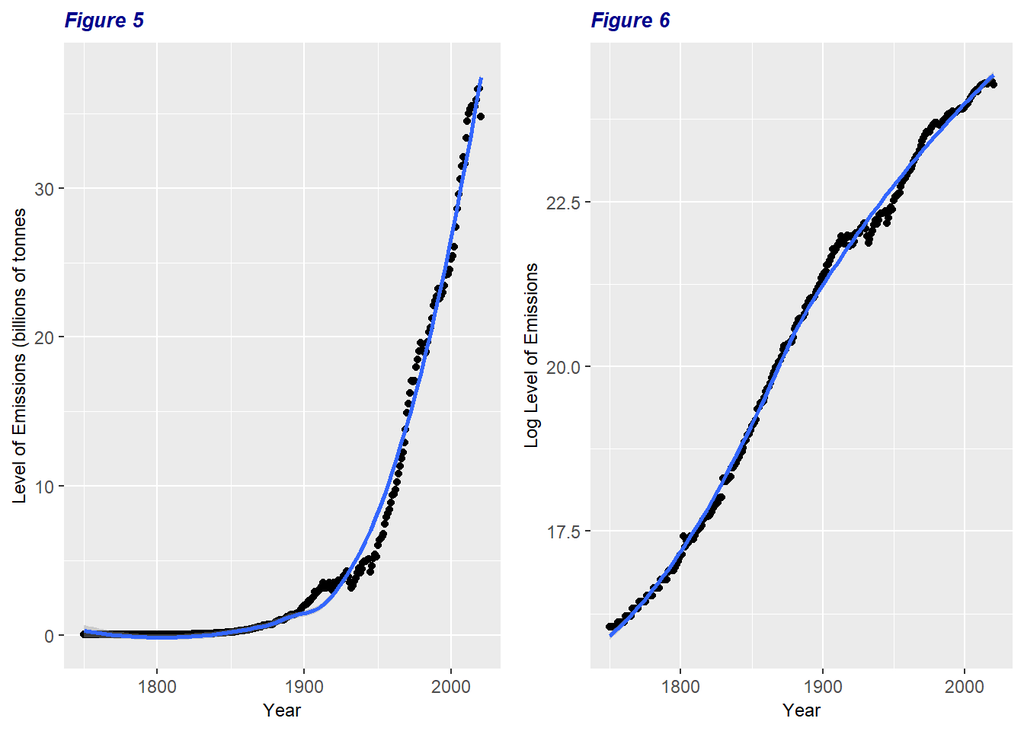

As I was looking at the graphs, I was curios when looking at Figure 6 if there was anything that explained the slight degrease in log emissions during the early-mid nineties. After a quick google search into a topic that could receive much more attention, the oscillation can likely be explained by the economic collapse of the Soviet Union and reorganization of several eastern European countries whose economies relied heavily on coal in energy production and in trade.

#### D E F O R E S T A T I O N

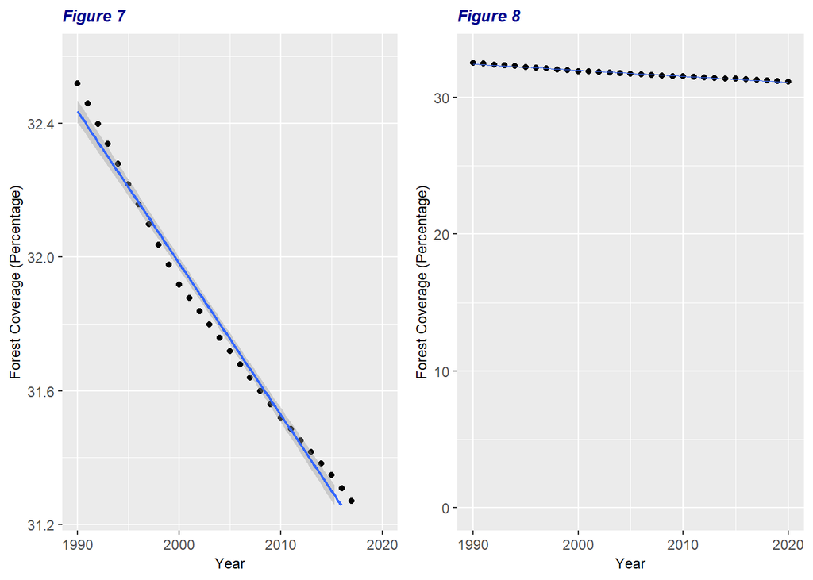

Considering the y-values of the graph is important as to not overstate or understand the change in the data. According to the World Resources Institute, the deforestation of tropical forests alone from 2015 to 2017 contributed to 4.8 billion tons of CO2 emissions each year (approximately 9% of annual carbon emissions). Even though such a time period would seem insignificant when looking at Figure 8, there are significant implications of such a change.

When thinking about deforestation, we must also think about additional consequences apart from less trees. Not only does deforestation remove trees that are natural carbon-traps, but methods of deforestation also contribute to emissions from their methods, whether that be from slash-and-burn techniques or the transportation emissions from the labor to cut down the trees.

#### M E T H A N E

Methane (CH4) emissions are the second largest contributor to greenhouse gas emissions. Some things that contribute to methane emissions include the digestive processes from livestock, emissions from energy and industry, and emissions from landfills and waste sites. If we look at Figure 9 below that contains data on methane emissions since 1990, we can see that global methane emissions are also upward trending over time.

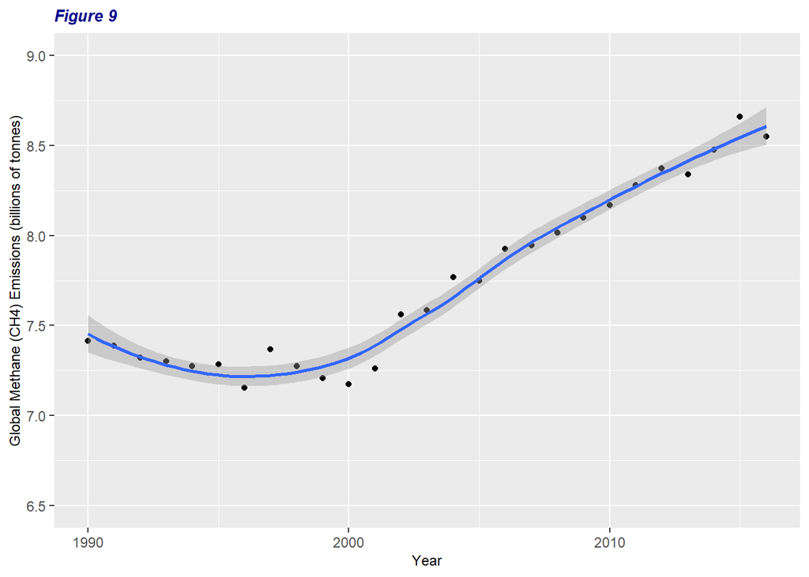

In Figures A-D below, we can see out NASA, carbon, deforestation, and methane emissions data for the years 1990 and onward. We can see that the trends as suggest what climate-change deniers don’t want to hear, that CO2 and CH4 emissions are positively associated with the trend in temperature anomies and negatively associated with rates of tree coverage.

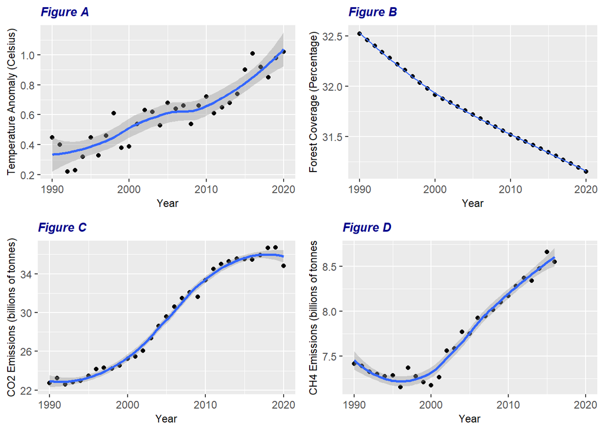

### Works Cited

Dean, A. (2019, August 21). Deforestation and the Carbon Cycle. Retrieved from Climate Council: https://www.climatecouncil.org.au/deforestation/

European Comission. (2021). EDGARv6.0 - Global Greenhouse Gas Emissions. Retrieved from EDGAR - Emissions Database for Global Atmospheric Research: https://edgar.jrc.ec.europa.eu/dataset_ghg60

NASA. (2021). GLOBAL Land-Ocean Temperature Index in 0.01 degrees Celsius . Retrieved from NASA GISTEMP4: https://data.giss.nasa.gov/gistemp/tabledata_v4/GLB.Ts+dSST.txt

Ritchie, H., & Roser, M. (2020). CO2 Emissions. Retrieved from Our World in Data: https://ourworldindata.org/co2-emissions

Ritchie, H., & Roser, M. (2020). Greenhouse Gas Emissions. Retrieved from Our World in Data: https://ourworldindata.org/greenhouse-gas-emissions

Ritchie, H., & Roser, M. (2021). Deforestation and Forest Loss. Retrieved from Our World in Data: https://ourworldindata.org/deforestation#forest-transitions-why-do-we-lose-then-regain-forests

Wald, M. (1991, December 8). Carbon Dioxide Emissions Dropped in 1990, Ecologists Say. Retrieved from New York Times: https://www.nytimes.com/1991/12/08/world/carbon-dioxide-emissions-dropped-in-1990-ecologists-say.html

World Data Center for Paleoclimatology - Boulder; NOAA Paleoclimatology Program. (2005). 2,000-Year Northern Hemisphere Temperature Reconstruction . Retrieved from Two Degree Institute: https://www.climatelevels.org/files/nhtemp-moberg2005.txt